# 01. `terra` 패키지

- 공간데이터란 지리적 위치, 즉 지구상의 장소에 관한 데이터

## 01.01. 공간 데이터

- 공간 현상은 일반적으로 경계가 명확한 이산형, 또는 어디에서나 관찰할 수 있지만 자연적인 경계가 없는 연속형으로 간주가능
  - 이산형 객체는 강, 도로, 국가, 도시 또는 연구 장소를 의미할 수 있음
  - 연속형 객체 "공간 필드"의 예로는 고도, 온도 및 대기질이 존재
- 공간 객체는 일반적으로 벡터 데이터로 표현
- 데이터는 객체의 "기하학" 또는 "모양"에 대한 설명으로 구성되며 일반적으로 추가 변수도 포함
  - 벡터는 세계 국가의 경계(기하학)를 나타낼 수 있음
  - 해당 국가의 이름과 2015년 인구 규모도 저장 가능
  - 해당 지역의 도로 형상과 유형 및 이름이 될 수도 있음
- **추가 변수는 종종 "속성"(attributes)라고 하며. 연속적인 공간 데이터(필드)는 일반적으로 래스터(raster) 데이터 구조로 표현**

### 벡터 데이터

- **벡터 데이터 유형은 점, 선, 네트워크, 다각형이 존재하며, 데이터 구조는 좌표 (x, y)로 구성**

#### 점 (Point)

- **각 점에는 하나의 좌표 쌍과 n개의 관련 변수가 존재**
  - **예) 각 점은 쥐가 갇힌 장소를 나타낼 수 있으며, 속성에는 쥐가 잡힌 날짜, 쥐를 잡은 사람, 종의 크기와 성별, 서식지에 대한 정보가 포함될 수 있음**
- 단일 속성 레코드를 사용하여, 여러 포인트를 다중 포인트 구조로 결합하는 것도 가능
  - 예) 한 마을의 모든 커피숍은 단일 기하학으로 간주

#### 선 (Line)

- **'선'은 하나 이상의 폴리라인(연결된 일련의 선분) 집합을 의미**
  - 예) 강과 모든 지류는 단일 '선'으로 간주, 그러나 각 지류 강에 대해 하나씩 여러 개의 선이 될 수도 있음
- 선은 순서가 지정된 좌표 집합(노드)으로 표시
  - 선분은 점을 연결하여 계산하고 지도에 그릴 수 있음
- **선의 표현은 다중점 구조의 표현과 매우 유사**
  - **주요 차이점은 선의 경우 점을 어떤 순서로 연결해야 하는지 알아야 하기 때문에 점의 순서가 중요**

#### 네트워크 (Network)

- **네트워크(예: 도로 또는 강 네트워크) 또는 공간 그래프는 흐름, 연결성, 방향, 거리 등에 대한 추가 정보가 있는 특별한 유형의 선 (Line)**

#### 다각형 (Polygon)

- **다각형은 닫힌 형태의 선의 집합**
  - **다각형의 계산은 선과 매우 유사하지만, 마지막 좌표 쌍이 첫 번째 쌍과 일치해야 완전히 닫힌 모양의 다각형이 완성**
- **다각형은 내부에 구멍을 포함할 수 있음**

  **(즉, 둘러싸는 다각형의 일부를 제거하는 역할을 하는, 완전히 둘러싸인 다른 다각형(예: 호수 내부의 섬을 표시).**
- 유효한 다각형은 내부 자체적으로 교차점이 존재하지 않음 (그러나 선이 자체 교차하는 것은 괜찮음).
  - 예) 인도네시아는 많은 섬으로 이루어져 있으며, 각 섬은 단일 다각형으로 표시될 수 있지만 함께 표시하면 전체 국가를 나타내는 단일(다중) 다각형을 나타낼 수 있음

### `Raster` 데이터

- **일반적으로 고도와 같은 공간적으로 연속적인 현상을 나타내는 데 사용**
- **`Raster`데이터는 공간을 관심 변수에 대해 하나 이상의 값(또는 누락된 값)을 갖는 동일한 크기의 직사각형(셀 또는 위성 원격 감지의 맥락에서 픽셀이라고 함)의 격자로 나눔**
- `Raster` 셀 값은 일반적으로 해당 셀이 포함하는 영역의 평균 (또는 다수) 값을 나타내야 함
  - **그러나 어떤 경우에는 값이 실제로 셀 중심에 대한 추정치(본질적으로 속성(attributes) 있는 일반적인 점 집합이 됨).**
- **벡터 데이터와 달리 `Raster` 데이터에서는 명시적으로 좌표로 저장되지 않으며, 공간 범위와 영역이 분할되는 행과 열의 수를 알면 암시적으로 설정**
- 행과 열의 범위와 수로부터 `Raster` 셀의 크기(공간 해상도)를 계산할 수 있음
  - `Raster` 셀은 정다각형의 집합으로 생각할 수 있지만, 각 셀의 좌표를 명시적으로 저장해야 하는 방식으로 데이터를 표현하는 것은 매우 비효율적

### 공간 데이터의 표현

#### 10개의 기상 관측소(A부터 J까지)의 위치(경도와 위도로 표시)와 해당 연간 강수량을 가지고 있다고 가정

- x, y 좌표에 대한 산점도, 점의 크기는 강수량에 비례

```r
name <- LETTERS[1:10]
longitude <- c(-116.7, -120.4, -116.7, -113.5, -115.5,
               -120.8, -119.5, -113.7, -113.7, -110.7)
latitude <- c(45.3, 42.6, 38.9, 42.1, 35.7, 38.9,
              36.2, 39, 41.6, 36.9)
stations <- cbind(longitude, latitude)
```

```r
set.seed(0)
precip <- round((runif(length(latitude))*10)^3)
```

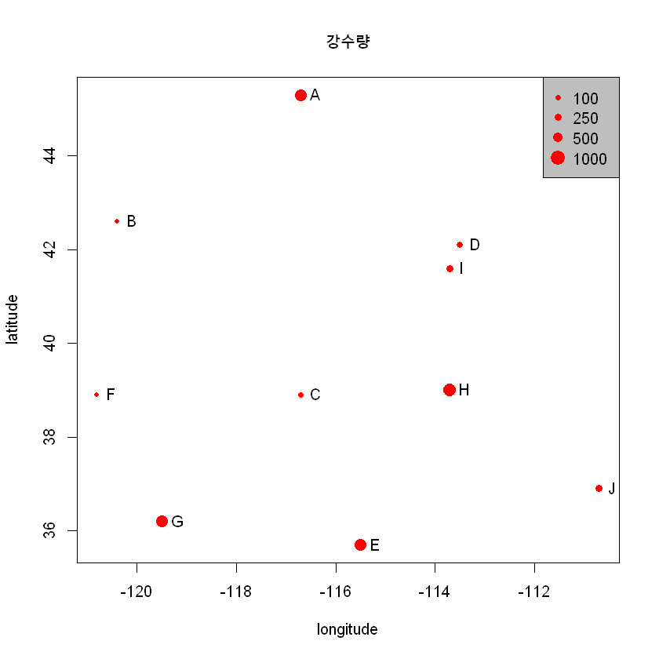

```r
psize <- 1 + precip/500
plot(stations, cex=psize, pch=20, col='red', main='강수량')
text(stations, name, pos=4)
breaks <- c(100, 250, 500, 1000)
legend.psize <- 1+breaks/500
legend("topright", legend=breaks, pch=20, pt.cex=legend.psize, col='red', bg='gray')
```

- 여러 점 집합을 추가하고, 선과 다각형을 표현

```r
lon <- c(-116.8, -114.2, -112.9, -111.9, -114.2, -115.4, -117.7)
lat <- c(41.3, 42.9, 42.4, 39.8, 37.6, 38.3, 37.6)
x <- cbind(lon, lat)
```

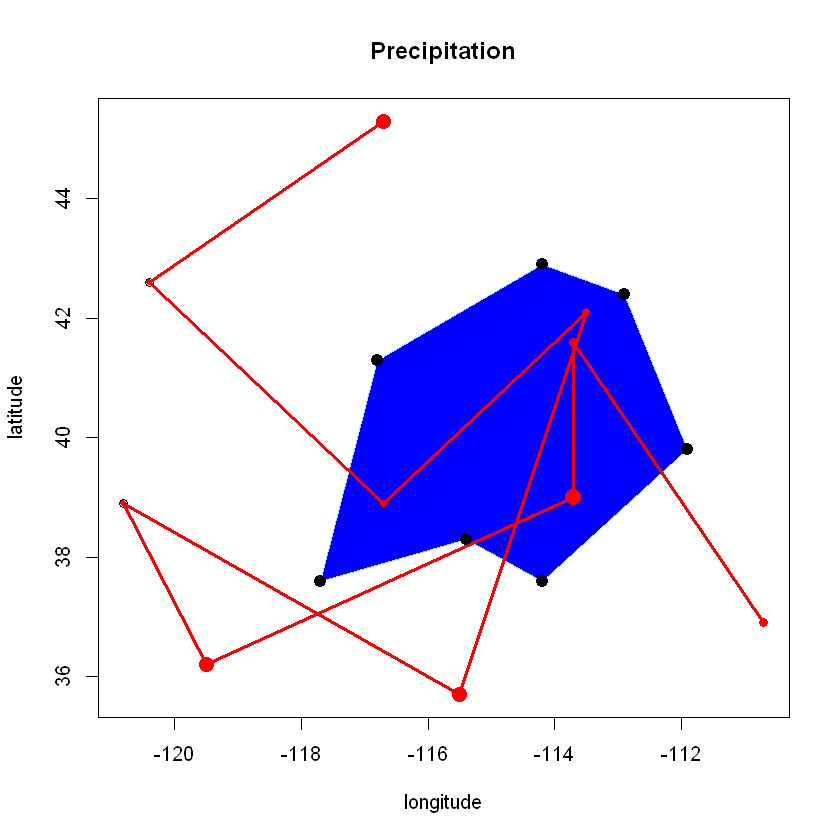

```r
plot(stations, main='Precipitation')
polygon(x, col='blue', border='light blue')
lines(stations, lwd=3, col='red')
points(x, cex=2, pch=20)
points(stations, cex=psize, pch=20, col='red', main='Precipitation')
```

## 01.02. `terra` 패키지 - 벡터 데이터

- `terra` 패키지는 공간 데이터를 나타내는 클래스 세트를 정의
- 클래스는 특정 데이터 유형을 정의하며. data.frame은 클래스의 예
- 생성한 특정 데이터 프레임은 해당 클래스의 객체(인스턴스화)
- `terra`는 이름에 `Spat`으로 시작하는 여러 클래스를 생성하며,

  **벡터 데이터의 경우 `SpatVector`이며, 설명변수 및 설명변수를 설명하는 속성(변수)도 포함**

### 점 (Points)

#### `terra::vect()` : `SpatVector` 객체 생성

- **`type`** : `points`, `lines`, `polygons`

```r
library(terra)
library(tidyverse)
```

```r
longitude <- c(-116.7, -120.4, -116.7, -113.5, -115.5, -120.8, -119.5, -113.7, -113.7, -110.7)
latitude <- c(45.3, 42.6, 38.9, 42.1, 35.7, 38.9, 36.2, 39, 41.6, 36.9)
lonlat <- cbind(longitude, latitude)
```

```r
pts <- vect(lonlat, type='points')
```

```r
class(pts)
```

'SpatVector'

```r
pts
```

```
 class       : SpatVector
 geometry    : points
 dimensions  : 10, 0  (geometries, attributes)
 extent      : -120.8, -110.7, 35.7, 45.3  (xmin, xmax, ymin, ymax)
 coord. ref. :
```

```r
crs(pts)
```

''

#### CRS (coordinate reference system, 좌표계) 정보 추가

```r
crdref <- "+proj=longlat +datum=WGS84"
pts <- vect(lonlat, crs=crdref)
pts
```

```
 class       : SpatVector
 geometry    : points
 dimensions  : 10, 0  (geometries, attributes)
 extent      : -120.8, -110.7, 35.7, 45.3  (xmin, xmax, ymin, ymax)
 coord. ref. : +proj=longlat +datum=WGS84 +no_defs
```

```r
crs(pts)
```

'GEOGCRS["unknown",\n DATUM["World Geodetic System 1984",\n ELLIPSOID["WGS 84",6378137,298.257223563,\n LENGTHUNIT["metre",1]],\n ID["EPSG",6326]],\n PRIMEM["Greenwich",0,\n ANGLEUNIT["degree",0.0174532925199433],\n ID["EPSG",8901]],\n CS[ellipsoidal,2],\n AXIS["longitude",east,\n ORDER[1],\n ANGLEUNIT["degree",0.0174532925199433,\n ID["EPSG",9122]]],\n AXIS["latitude",north,\n ORDER[2],\n ANGLEUNIT["degree",0.0174532925199433,\n ID["EPSG",9122]]]]'

#### `SpatVector` 객체에 속성(attributes)를 추가

- 데이터와 동일한 행 수를 가진 속성정보 데이터 프레임

```r
precipvalue <- runif(nrow(lonlat), min=0, max=100)
df <- data.frame(ID=1:nrow(lonlat), precip=precipvalue)
```

```r
pts %>% dim
```

1. 10

2. 0

```r
df %>% dim
```

1. 10

2. 2

- 속성정보를 `SpatVector` 객체에 포함

```r
ptv <- vect(lonlat, atts=df, crs=crdref)
```

```r
ptv
```

```
 class       : SpatVector
 geometry    : points
 dimensions  : 10, 2  (geometries, attributes)
 extent      : -120.8, -110.7, 35.7, 45.3  (xmin, xmax, ymin, ymax)
 coord. ref. : +proj=longlat +datum=WGS84 +no_defs
 names       :    ID precip
 type        : <int>  <num>
 values      :     1  6.179
                   2   20.6
                   3  17.66
```

### 선 (Line)과 다각형 (Polygon)

- **`vect()`의 `type`을 `lines`으로 설정하여 선 공간 생성**

```r
lon <- c(-116.8, -114.2, -112.9, -111.9, -114.2, -115.4, -117.7)
lat <- c(41.3, 42.9, 42.4, 39.8, 37.6, 38.3, 37.6)
lonlat <- cbind(id=1, part=1, lon, lat)
lonlat
```

A matrix: 7 × 4 of type dbl

| id | part | lon | lat |
| --- | --- | --- | --- |
| 1 | 1 | -116.8 | 41.3 |
| 1 | 1 | -114.2 | 42.9 |
| 1 | 1 | -112.9 | 42.4 |
| 1 | 1 | -111.9 | 39.8 |
| 1 | 1 | -114.2 | 37.6 |
| 1 | 1 | -115.4 | 38.3 |
| 1 | 1 | -117.7 | 37.6 |

```r
lns <- vect(lonlat, type="lines", crs=crdref)
lns
```

```
 class       : SpatVector
 geometry    : lines
 dimensions  : 1, 0  (geometries, attributes)
 extent      : -117.7, -111.9, 37.6, 42.9  (xmin, xmax, ymin, ymax)
 coord. ref. : +proj=longlat +datum=WGS84 +no_defs
```

- **`vect()`의 `type`을 `polygons`으로 설정하여 다각형 공간 생성**

```r
pols <- vect(lonlat, type="polygons", crs=crdref)
pols
```

```
 class       : SpatVector
 geometry    : polygons
 dimensions  : 1, 0  (geometries, attributes)
 extent      : -117.7, -111.9, 37.6, 42.9  (xmin, xmax, ymin, ymax)
 coord. ref. : +proj=longlat +datum=WGS84 +no_defs
```

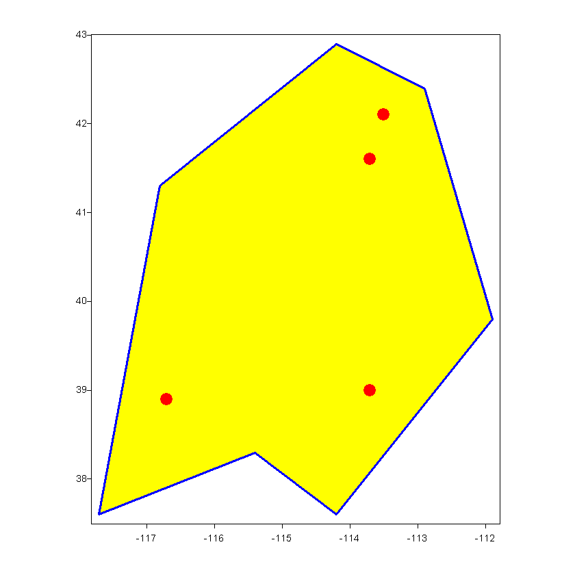

```r
plot(pols, las=1)
plot(pols, border='blue', col='yellow', lwd=3, add=TRUE)
points(pts, col='red', pch=20, cex=3)
```

## 02.03. `Raster` 데이터

- `terra` 패키지에는 래스터 데이터를 생성하고, 읽고, 조작하고, 쓰는 기능 존재

### `SpatRaster` 객체

- 다중 변수 `Raster` 데이터를 표현
- 형상을 설명하는 여러 기본 매개변수를 저장
  - 열과 행의 수, 공간 범위, 좌표 참조 시스템 등 이 포함
- `SpatRaster`는 `Raster` 셀 값이 저장된 파일에 대한 정보를 저장

#### `terra::rast()`

```r
r <- rast(ncol=10, nrow=10, xmin=-150, xmax=-80, ymin=20, ymax=60)
r
```

```
class       : SpatRaster
dimensions  : 10, 10, 1  (nrow, ncol, nlyr)
resolution  : 7, 4  (x, y)
extent      : -150, -80, 20, 60  (xmin, xmax, ymin, ymax)
coord. ref. : lon/lat WGS 84 (CRS84) (OGC:CRS84)
```

- **`SpatRaster`에는 좌표 정보만 존재. 즉, 위치, 해상도 등을 알고 있지만 이와 관련된 값은 없는 형태**

  **$\rightarrow$ `Raster` 데이터의 셀 수와 동일한 길이의 벡터를 값으로 할당**

```r
values(r) <- 1:ncell(r)
r
```

```
class       : SpatRaster
dimensions  : 10, 10, 1  (nrow, ncol, nlyr)
resolution  : 7, 4  (x, y)
extent      : -150, -80, 20, 60  (xmin, xmax, ymin, ymax)
coord. ref. : lon/lat WGS 84 (CRS84) (OGC:CRS84)
source(s)   : memory
name        : lyr.1
min value   :     1
max value   :   100
```

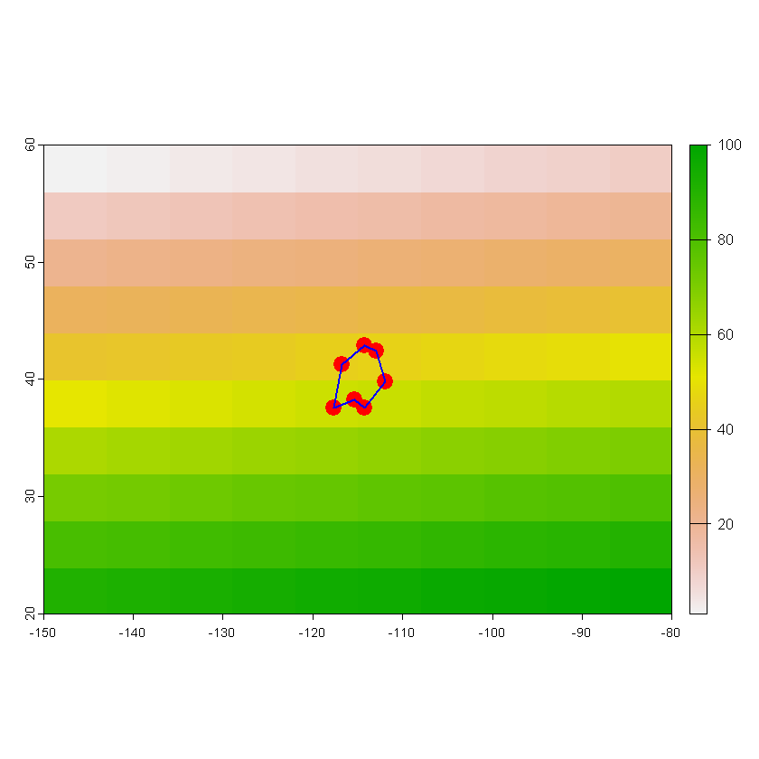

```r
plot(r)

lon <- c(-116.8, -114.2, -112.9, -111.9, -114.2, -115.4, -117.7)
lat <- c(41.3, 42.9, 42.4, 39.8, 37.6, 38.3, 37.6)
lonlat <- cbind(id=1, part=1, lon, lat)
pts <- vect(lonlat)
pols <- vect(lonlat, type="polygons", crs="+proj=longlat +datum=WGS84")
points(pts, col="red", pch=20, cex=3)
lines(pols, col="blue", lwd=2)
```

#### 다중 레이어 객체 생성

```r
r2 <- r * r
r3  <- sqrt(r)
s <- c(r, r2, r3)
s
```

```
class       : SpatRaster
dimensions  : 10, 10, 3  (nrow, ncol, nlyr)
resolution  : 7, 4  (x, y)
extent      : -150, -80, 20, 60  (xmin, xmax, ymin, ymax)
coord. ref. : lon/lat WGS 84 (CRS84) (OGC:CRS84)
source(s)   : memory
names       : lyr.1, lyr.1, lyr.1
min values  :     1,     1,     1
max values  :   100, 10000,    10
```

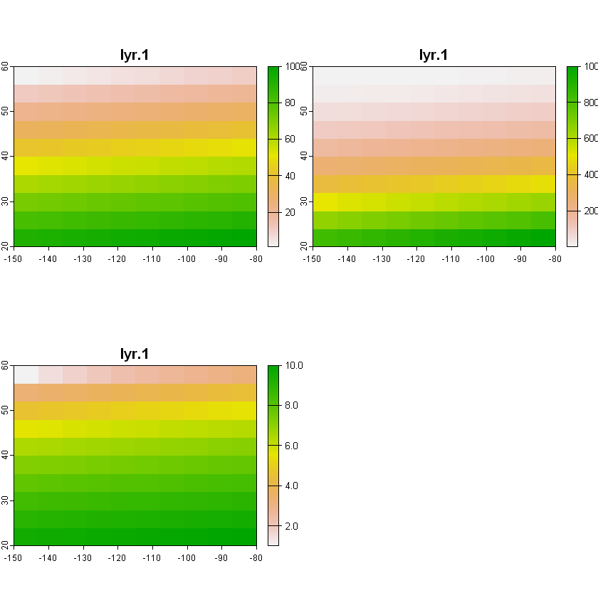

```r
plot(s)
```

## 01.04. 공간 데이터 조작

### 벡터 데이터

- `Shapefile`은 벡터 데이터에 가장 일반적으로 사용되는 파일 형식
- `Shapefile`은 최소 3개 (이상적으로는 4개) 파일의 집합 (이름은 모두 동일하지만 확장자가 모두 상이한 파일들의 집합)
  - 임의의 `Shapefile`인 `x`의 경우, 동일한 디렉터리에 `x.shp`, `x.shx`, `x.dbf` 3가지 파일이 존재해야 하며, 이상적으로는 `x.prj`파일도 존재해야 함

#### 읽기

```r
filename <- system.file("ex/lux.shp", package="terra")
basename(filename)
```

'lux.shp'

```r
vect(filename)
```

```
 class       : SpatVector
 geometry    : polygons
 dimensions  : 12, 6  (geometries, attributes)
 extent      : 5.74414, 6.528252, 49.44781, 50.18162  (xmin, xmax, ymin, ymax)
 source      : lux.shp
 coord. ref. : lon/lat WGS 84 (EPSG:4326)
 names       :  ID_1   NAME_1  ID_2   NAME_2  AREA   POP
 type        : <num>    <chr> <num>    <chr> <num> <int>
 values      :     1 Diekirch     1 Clervaux   312 18081
                   1 Diekirch     2 Diekirch   218 32543
                   1 Diekirch     3  Redange   259 18664
```

#### 쓰기

```r
outfile <- "shp_test.shp"
writeVector(s, outfile, overwrite=TRUE)
```

- 삭제

```r
ff <- list.files(patt="^shptest")
file.remove(ff)
```

### `Raster` 데이터

#### 읽기

```r
f <- system.file("ex/logo.tif", package="terra")
basename(f)
```

'logo.tif'

```r
r <- rast(f)
r
```

```
class       : SpatRaster
dimensions  : 77, 101, 3  (nrow, ncol, nlyr)
resolution  : 1, 1  (x, y)
extent      : 0, 101, 0, 77  (xmin, xmax, ymin, ymax)
coord. ref. : Cartesian (Meter)
source      : logo.tif
colors RGB  : 1, 2, 3
names       : red, green, blue
min values  :   0,     0,    0
max values  : 255,   255,  255
```

```r
r %>% dim
```

1. 77

2. 101

3. 3

```r
r2 <- r[[2]]
r2
```

```
class       : SpatRaster
dimensions  : 77, 101, 1  (nrow, ncol, nlyr)
resolution  : 1, 1  (x, y)
extent      : 0, 101, 0, 77  (xmin, xmax, ymin, ymax)
coord. ref. : Cartesian (Meter)
source      : logo.tif
name        : green
min value   :     0
max value   :   255
```

#### 쓰기

```r
x <- writeRaster(r, "test_output.tif", overwrite=TRUE)
x
```

```
class       : SpatRaster
dimensions  : 77, 101, 3  (nrow, ncol, nlyr)
resolution  : 1, 1  (x, y)
extent      : 0, 101, 0, 77  (xmin, xmax, ymin, ymax)
coord. ref. : Cartesian (Meter)
source      : test_output.tif
colors RGB  : 1, 2, 3
names       : red, green, blue
min values  :   0,     0,    0
max values  : 255,   255,  255
```

## 01.05. 좌표계 (CRS, Coordinate Reference Systems)

### 각도좌표 (Angular coordinates)

- 지구는 불규칙한 타원체 모양을 하고 있으며, **지리 데이터의 자연 좌표계는 경도/위도로서 각도 좌표계에 해당**
- 위도 (Latitude) $\phi$는 적도면과, 지구 중심점과 특정 점을 연결하는 한 선 사이의 각도
- 경도 (Longidue) $\lambda$는 기준 자오선(일정한 경도의 선)에서 해당 지점을 통과하는 자오선까지의 각도

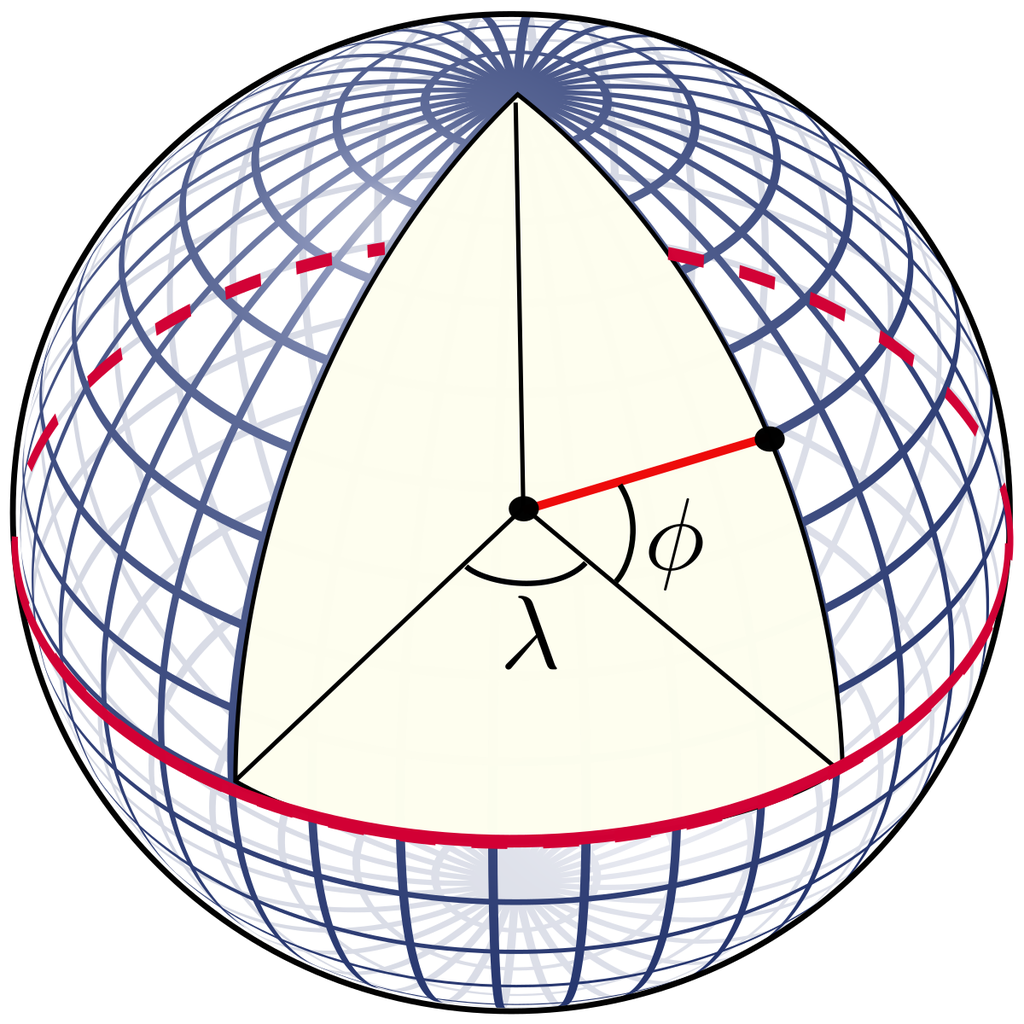

#### 데이텀 (Datum)

- **위도와 경도를 추정하기 위한 지구 모양의 모델 $\rightarrow$ 데이텀 (Datum)**
- **가장 간단한 데이텀은 회전타원체(극에서 "평탄화"되고 적도에서 부풀어오르는 구)**

  **데이텀이 더 복잡할수록 지구의 모양이 더 다양해짐**
- 가장 일반적으로 사용되는 데이텀은 WGS84(World Geodesic System 1984)
  - NAD83(The North American Datum of 1983)과 유사
  - 단일 국가 또는 지역의 위치를 보다 정확하게 기록하기 위해, 지역마다 다른 데이텀이 존재

#### 위치를 기록하는 기본 방법은 각도 단위의 좌표 쌍과 기준 데이텀

- 일반적으로 지리적 위치는 WGS84 데이텀을 기준으로 한 경도/위도를 의미
  - 마찬가지로 경도/위도 좌표는 "지리적" 좌표

### 투영 (Projections)

- **데이텀 모델을 통한 3차원 각도 시스템을 2차원 평면("데카르트") 시스템으로 변환하는 방법이 필요**
  - 평면 시스템은 특정 계산에 사용하기가 더 쉽고 지도를 만드는 데 필요
- 다양한 유형의 평면 좌표계들을 "투영"이라 부르며, 일부 투영법은 전 세계 지도에 적용될 수 있음
- **지도 투영의 가장 중요한 특징 중 하나는, "동일한 면적"(지도의 축척이 일정함)인지 "등각"(지리적 특징의 모양이 지구본에서 보이는 것과 같음)인지 여부**
  - 2차원 지도 투영은 등각적이면서 면적이 동일할 수 없으며(그러나 대략적으로 작은 면적의 경우, 둘 다일 수 있음), 일부는 둘 다 아닐 수도 있음

### 표기법 (Notation)

- 평면 좌표계는 투영, 데이텀 및 매개변수 세트로 정의
  - 매개변수는 지도의 중심 위치 등을 결정. 매개변수의 수는 투영법에 따라 상이.
  - 따라서 사용된 투영법을 문서화하는 것은 쉽지 않으며 여러 시스템이 존재
  - R에서는 PROJ.4 표기법을 사용 (PROJ.4)는 CRS 변환에 일반적으로 사용되는 소프트웨어 라이브러리)
    - PROJ.4 표기법은 최신 버전의 라이브러리에서 더이상 완전히 지원되지 않음 (이름이 $PR\phi J$로 변경 됨
    - WGS84 데이텀을 사용하는 CRS에서는 여전히 작동
    - 다른 경우에는 EPSG 코드(사용 가능한 경우) 또는 Well-Known-Text 표기법을 사용
- 가장 일반적으로 사용되는 CRS에는 "EPSG 코드" (EPSG는 European Petroleum Survey Group을 나타냄).
  - 이는 CRS를 식별하는 간단한 방법이 될 수 있는 고유 ID
  - 예) EPSG에서의 `EPSG:27561`는

    `+proj=lcc +lat_1=49.5 +lat_0=49.5 +lon_0=0 +k_0=0.999877341 +x_0=6 +y_0=2 +a=6378249.2 +b=6356515 +towgs84=-168,-60,320,0,0,0,0 +pm=paris +units=m +no_defs`과 동일

#### 데이터의 좌표계 확인

```r
f <- system.file("ex/lux.shp", package="terra")
p <- vect(f)
p
```

```
 class       : SpatVector
 geometry    : polygons
 dimensions  : 12, 6  (geometries, attributes)
 extent      : 5.74414, 6.528252, 49.44781, 50.18162  (xmin, xmax, ymin, ymax)
 source      : lux.shp
 coord. ref. : lon/lat WGS 84 (EPSG:4326)
 names       :  ID_1   NAME_1  ID_2   NAME_2  AREA   POP
 type        : <num>    <chr> <num>    <chr> <num> <int>
 values      :     1 Diekirch     1 Clervaux   312 18081
                   1 Diekirch     2 Diekirch   218 32543
                   1 Diekirch     3  Redange   259 18664
```

```r
crs(p)
```

'GEOGCRS["WGS 84",\n DATUM["World Geodetic System 1984",\n ELLIPSOID["WGS 84",6378137,298.257223563,\n LENGTHUNIT["metre",1]]],\n PRIMEM["Greenwich",0,\n ANGLEUNIT["degree",0.0174532925199433]],\n CS[ellipsoidal,2],\n AXIS["geodetic latitude (Lat)",north,\n ORDER[1],\n ANGLEUNIT["degree",0.0174532925199433]],\n AXIS["geodetic longitude (Lon)",east,\n ORDER[2],\n ANGLEUNIT["degree",0.0174532925199433]],\n ID["EPSG",4326]]'

### 좌표계 할당

- 좌표계가 할당되지 않은 데이터

```r
pp <- p
crs(pp) <- ""
crs(pp)
```

''

#### `terra::project()` : 좌표계 할당

- **좌표계 할당 후, 데이터의 단위는 더이상 위도/경도가 아닌,**

  **(경도=0, 위도=0)에서 떨어진 거리의 미터**

```r
newcrs <- "+proj=robin +datum=WGS84"
```

```r
rob <- terra::project(p, newcrs)
rob
```

```
 class       : SpatVector
 geometry    : polygons
 dimensions  : 12, 6  (geometries, attributes)
 extent      : 471320.7, 536010.5, 5269709, 5345677  (xmin, xmax, ymin, ymax)
 coord. ref. : +proj=robin +lon_0=0 +x_0=0 +y_0=0 +datum=WGS84 +units=m +no_defs
 names       :  ID_1   NAME_1  ID_2   NAME_2  AREA   POP
 type        : <num>    <chr> <num>    <chr> <num> <int>
 values      :     1 Diekirch     1 Clervaux   312 18081
                   1 Diekirch     2 Diekirch   218 32543
                   1 Diekirch     3  Redange   259 18664
```

#### 데이터를 위도/경도로 복구

```r
p2 <- terra::project(rob, "+proj=longlat +datum=WGS84")
```

### `Raster` 데이터 변환

- **벡터 데이터는 정밀도 손실 없이 경도/위도 좌표에서 평면형으로 또는 그 반대로 변환될 수 있지만, `Raster` 데이터의 경우에는 그렇지 않음**
  - **`Raster`는 동일한 크기(CRS 단위 기준, 실제 크기는 다를 수 있음)의 직사각형 셀로 구성되며, 셀 단위로 변환이 불가능**

    $\rightarrow$ 각각의 새 셀에 대해 겹치는 이전 셀의 값을 기반으로 값을 추정해야 하며,

    값이 범주형 데이터인 경우 "최근접 이웃" 방법이 일반적으로 사용.

    그렇지 않으면 일종의 보간법이 사용
  - `Raster` 데이터에 대한 투영은, 셀 값에 영향을 주기에, 대부분의 경우 `Raster`에 직접적인 투영을 피하고 벡터 데이터 투영을 진행

#### `Raster` 데이터의 투영

- `Raster` 기반 분석의 경우, 특히 넓은 영역을 분석할 때 동일한 영역 투영을 사용하는 것이 중요한 경우가 많으며
- 그리드 셀의 크기가 모두 동일해야, 개수 데이터를 사용할 때 비교 분석에 용이

```r
r <- rast(xmin=-110, xmax=-90, ymin=40, ymax=60, ncols=40, nrows=40)
values(r) <- 1:ncell(r)
r
```

```
class       : SpatRaster
dimensions  : 40, 40, 1  (nrow, ncol, nlyr)
resolution  : 0.5, 0.5  (x, y)
extent      : -110, -90, 40, 60  (xmin, xmax, ymin, ymax)
coord. ref. : lon/lat WGS 84 (CRS84) (OGC:CRS84)
source(s)   : memory
name        : lyr.1
min value   :     1
max value   :  1600
```

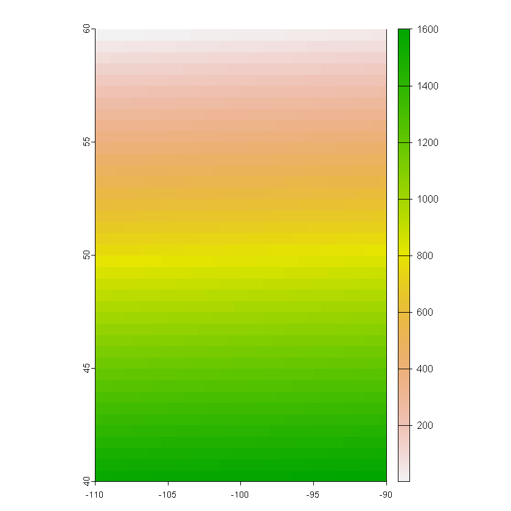

```r
plot(r)
```

```r
pr1 <- terra::project(r, newcrs)
pr1
```

```
class       : SpatRaster
dimensions  : 55, 75, 1  (nrow, ncol, nlyr)
resolution  : 37319.55, 37319.55  (x, y)
extent      : -9577685, -6778719, 4283463, 6336039  (xmin, xmax, ymin, ymax)
coord. ref. : +proj=robin +lon_0=0 +x_0=0 +y_0=0 +datum=WGS84 +units=m +no_defs
source(s)   : memory
name        :       lyr.1
min value   :    1.139816
max value   : 1600.000000
```

'PROJCRS["unknown",\n BASEGEOGCRS["unknown",\n DATUM["World Geodetic System 1984",\n ELLIPSOID["WGS 84",6378137,298.257223563,\n LENGTHUNIT["metre",1]],\n ID["EPSG",6326]],\n PRIMEM["Greenwich",0,\n ANGLEUNIT["degree",0.0174532925199433],\n ID["EPSG",8901]]],\n CONVERSION["unknown",\n METHOD["Robinson"],\n PARAMETER["Longitude of natural origin",0,\n ANGLEUNIT["degree",0.0174532925199433],\n ID["EPSG",8802]],\n PARAMETER["False easting",0,\n LENGTHUNIT["metre",1],\n ID["EPSG",8806]],\n PARAMETER["False northing",0,\n LENGTHUNIT["metre",1],\n ID["EPSG",8807]]],\n CS[Cartesian,2],\n AXIS["(E)",east,\n ORDER[1],\n LENGTHUNIT["metre",1,\n ID["EPSG",9001]]],\n AXIS["(N)",north,\n ORDER[2],\n LENGTHUNIT["metre",1,\n ID["EPSG",9001]]]]'

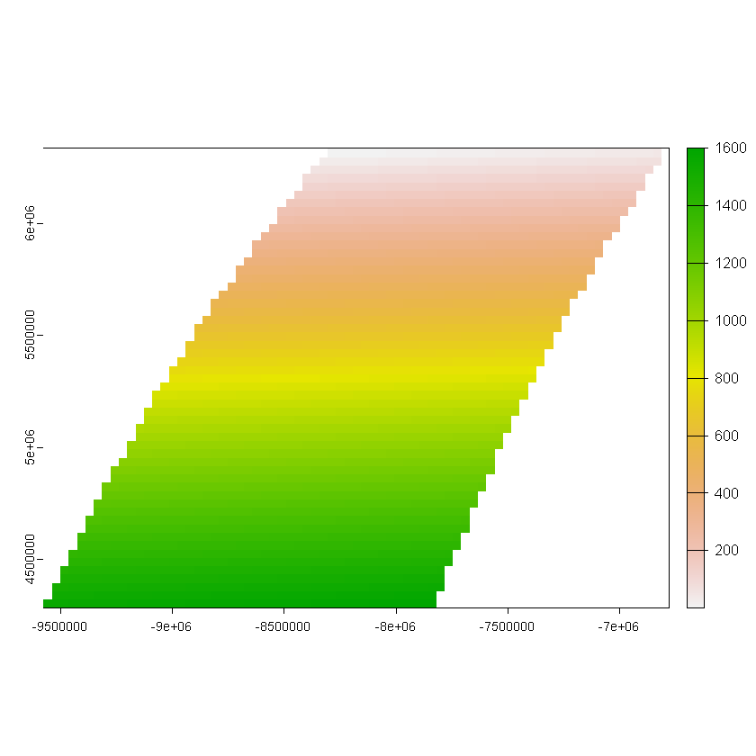

```r
crs(pr1)
plot(pr1)
```

```r
x <- rast(pr1)
res(x) <- 200000
```

```
class       : SpatRaster
dimensions  : 10, 14, 1  (nrow, ncol, nlyr)
resolution  : 2e+05, 2e+05  (x, y)
extent      : -9577685, -6777685, 4283463, 6283463  (xmin, xmax, ymin, ymax)
coord. ref. : +proj=robin +lon_0=0 +x_0=0 +y_0=0 +datum=WGS84 +units=m +no_defs
source(s)   : memory
name        :     lyr.1
min value   :  111.1541
max value   : 1523.5796
```

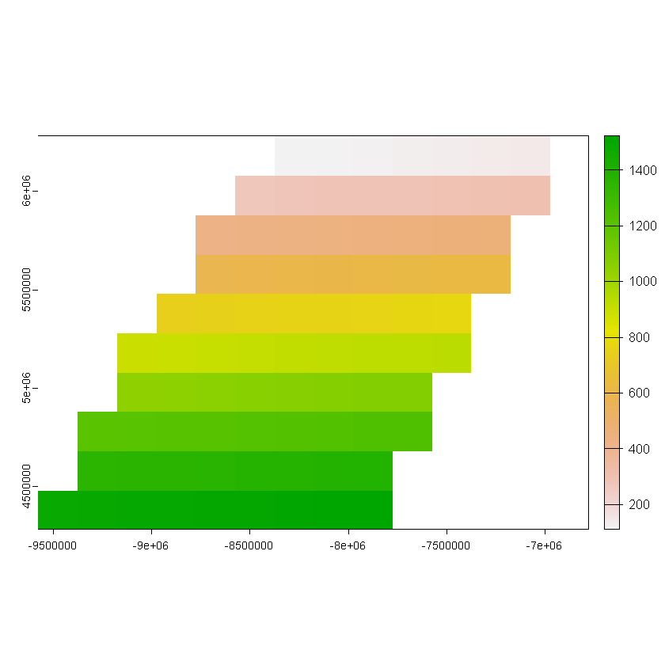

```r
pr3 <- terra::project(r, x)
pr3
plot(pr3)
```